# Question

In [Desmos](https://www.desmos.com/calculator), we can get best-fit curves by using their [least-squares regression](https://en.wikipedia.org/wiki/Least_squares) tool. This type of analysis is very important in science and research.

In this problem, I want you to run a cubic regression on the following points:

| x | y |
| --- | --- |
| 2 | 9 |
| 3 | 4 |
| 5 | 1 |
| 6 | 5 |
| 8 | 3 |

The result of the regression will be a cubic polynomial, which we can call $f$. You will then evaluate $f(9)$.

If you copy/paste the above table into a Desmos item, it should create a table. If not, add a new table and add the points shown above.

In that item’s top-left corner, there should be a “Add Regression” button; click it. Change the regression type to “Cubic Regression”. You’ll see a cubic curve that does its best to get as close to the points as possible. You can “Export a snapshot to the expression list” by clicking on the button next to `EQUATION`. In that new expression, replace the $y$ with $f(x)$.

Now, in a new item, you should be able to evaluate $f(9)$. What do you get? (We are using regression to make a prediction. The tolerance is $\pm0.01$.)

# Solution

Your cubic regression should give the following polynomial.

$$f(x)~=~{-0.2895}x^{3}+{4.778}x^{2}-{24.5}x+{41.53}$$

So, $f(9)=-2.9548872$.

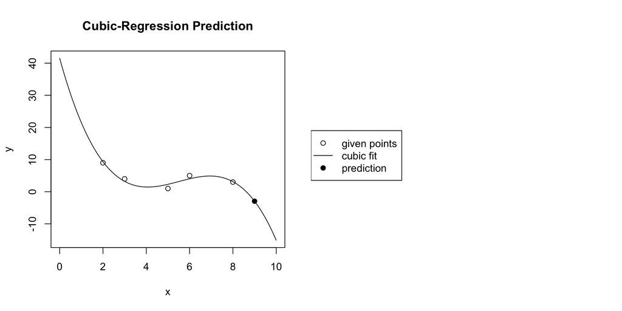

# Meta-information

extype: num exsolution: -2.9548872 exname: cubic_regression extol: 0.01